# Chapter 1

## Section 1.2

Examples of time series data

### Example 1.1 J&J Quarterlies

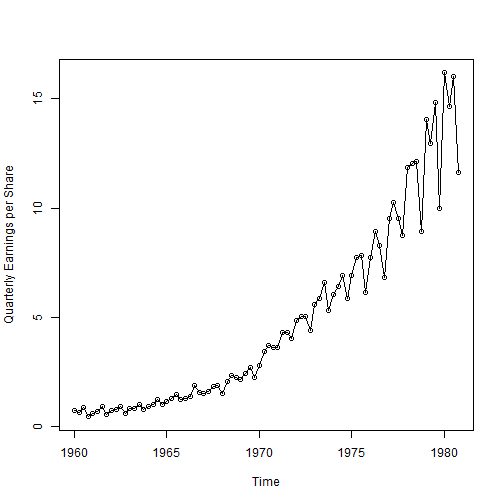

```r
library(astsa)
plot(jj, type = "o", ylab = "Quarterly Earnings per Share")
```

Note the generally upward trend with minor variations. Variations increase as time goes on, as well.

### Example 1.2 Global Warming

Time series data is its own data type in R with a default print function

```r
head(gtemp)
```

```
## [1] -0.28 -0.21 -0.26 -0.27 -0.32 -0.32
```

```r
class(gtemp)
```

```
## [1] "ts"
```

```r
summary(gtemp)
```

```
##     Min.  1st Qu.   Median     Mean  3rd Qu.     Max.
## -0.39000 -0.21750 -0.05000 -0.02162  0.09750  0.62000
```

```r
str(gtemp)
```

```
##  Time-Series [1:130] from 1880 to 2009: -0.28 -0.21 -0.26 -0.27 -0.32 -0.32 -0.29 -0.36 -0.27 -0.17 ...
```

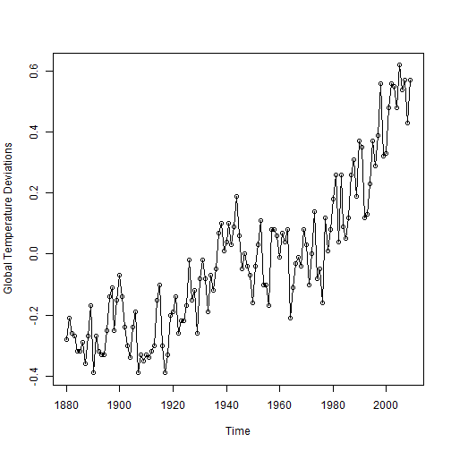

```r
plot(gtemp, type = "o", ylab = "Global Temperature Deviations")
```

Deviations from global mean temperature 1951 - 1980. Note the major upward trend, but with other oscillations throughout.

### Example 1.3 Speech data

0.1 sec sample of recorded speech for *aaaaaaaaahhhhhh*.

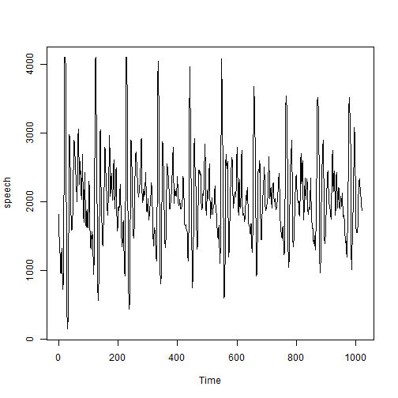

```r
plot(speech)
```

Hugely repetitive, regular periodicities. Can use spectral analysis (eigenbased methods) to create “signature” in further analysis, matching signature to other tokens can be used to identify similarities, cluster, etc.

### Example 1.4 NYSE

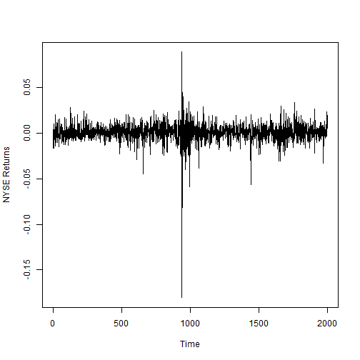

```r
plot(nyse, ylab = "NYSE Returns")
```

Mostly stable average w/ lots of variance. Huge drop/volatility corresponds to drop in Oct. 1987.

#### Example 1.5 El Nino and Fish Pop.

Southern Oscillation Index (SOI) corresponds to El Nino, Recruitment to number of new fish.

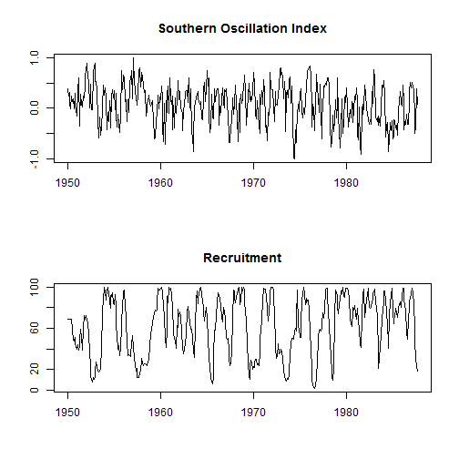

```r
par(mfrow = c(2, 1)) ## 2x1 grid for plotting
plot(soi, ylab = "", xlab = "", main = "Southern Oscillation Index")
plot(rec, ylab = "", xlab = "", main = "Recruitment")
```

```r
par(mfrow = c(1, 1)) ## return to default
```

Both repetitive. SOI is faster period than recruitment. Recruitment has two underlying oscillations. Faster period repeating yearly, but notice drops approx. 4 years apart.